# Dow Jones Data Challenge

```r
#installing necessary packages
library(dplyr)
library(naniar)
library(magrittr)
library(ggplot2)
library(readr)
library(DT)
```

Reading our dataset

```r
dataset <- read_csv("~/Desktop/DowJones/dataset.csv")
#first 6 rows of our dataset
head(dataset)
```

| recordDate | rowNumber | bundle | accountCreationDate | subscriptionBeginDate | subscriptionEndDate | activeDays | activeDaysLastMonth | newsletterActivated | appActivated | activeDaysThisWeek | devicesCount | visitsWeb | visitsApps | articleViewsWeb | articleViewsApps | articlesPerVisitWeb | articlesPerVisitApps | desktop | mobile | mac | favoriteSection | viewsOpinion | viewsPolitics | viewsBusiness | viewsMarkets | viewsWorld | viewsLife | viewsTech | viewsUS | … |
| --- | --- | --- | --- | --- | --- | --- | --- | --- | --- | --- | --- | --- | --- | --- | --- | --- | --- | --- | --- | --- | --- | --- | --- | --- | --- | --- | --- | --- | --- | --- |
| 6/3/20 | 1 | Digital Plus + Print | 10/19/09 | 1/11/12 | NA | 3 | 3 | 0 | 1 | 1 | 1 | 0 | 3 | 0 | 10 | NA | 1 | 0 | 1 | 1 | Opinion | 3 | 0 | 0 | 0 | 0 | 0 | 0 | 0 | … |
| 6/3/20 | 2 | Digital Plus | 3/23/15 | 3/23/15 | NA | 1 | 0 | 0 | 1 | 0 | 1 | 0 | 1 | 0 | 1 | NA | 1 | 0 | 1 | 1 | World | 0 | 0 | 0 | 0 | 1 | 0 | 0 | 0 | … |
| 6/3/20 | 3 | Ultimate Package | 10/22/09 | 1/14/20 | NA | 8 | 4 | 1 | 1 | 2 | 2 | 3 | 7 | 6 | 16 | 2.000000 | 1 | 1 | 1 | 1 | Opinion | 5 | 2 | 0 | 0 | 0 | 0 | 0 | 0 | … |
| 6/3/20 | 4 | Digital Plus + Print | 10/19/09 | 6/26/17 | NA | 28 | 27 | 0 | 1 | 7 | 4 | 2 | 133 | 3 | 288 | 1.500000 | 1 | 0 | 1 | 1 | Opinion | 59 | 3 | 9 | 8 | 3 | 9 | 2 | 17 | … |
| 6/3/20 | 5 | Digital Package | 10/19/09 | 4/26/18 | NA | 17 | 18 | 1 | 1 | 3 | 17 | 21 | 0 | 31 | 0 | 1.476190 | NA | 1 | 1 | 1 | Business | 0 | 3 | 9 | 6 | 2 | 0 | 4 | 4 | … |
| 6/3/20 | 6 | Digital Package | 12/6/11 | 8/27/17 | NA | 6 | 5 | 1 | 0 | 1 | 1 | 7 | 0 | 8 | 0 | 1.142857 | NA | 0 | 1 | 0 | Markets | 0 | 0 | 1 | 2 | 0 | 2 | 2 | 0 | … |

Dimensions of our dataset

```r
dim(dataset)
```

```
[1] 200000     43
```

Checking for missing values

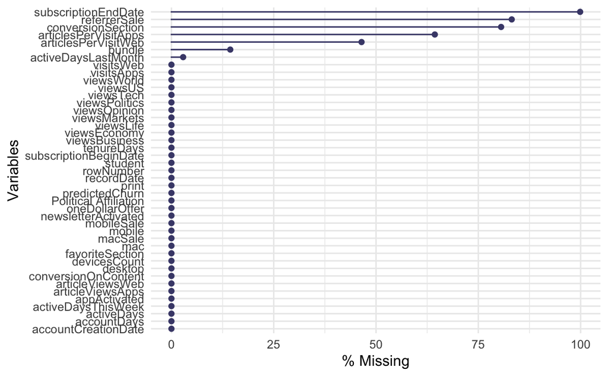

Checking for outliers

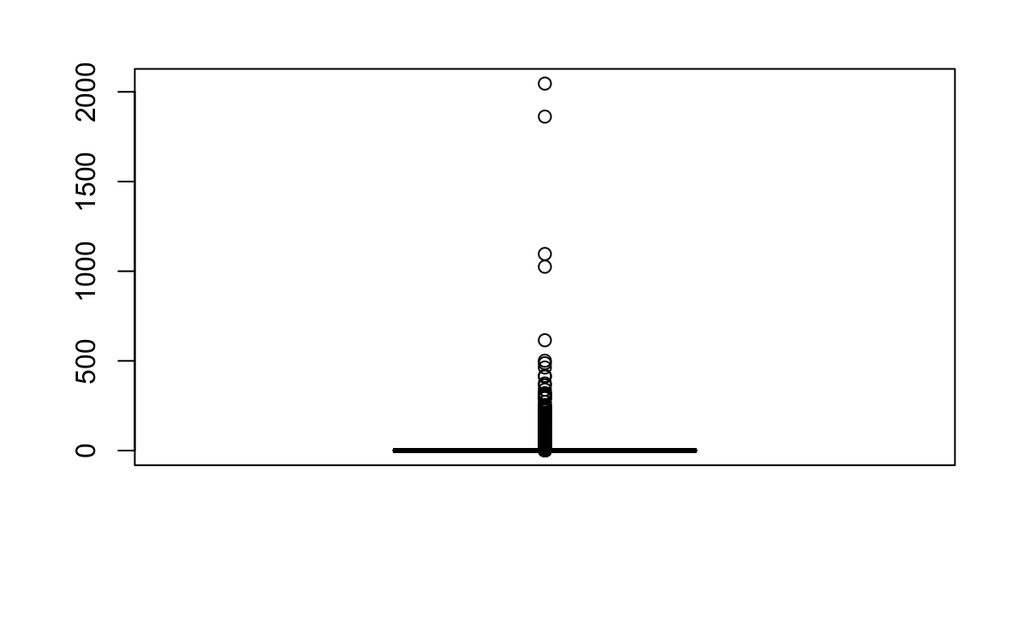

```r
quantile(dataset$viewsPolitics)
```

```
  0%  25%  50%  75% 100%
   0    0    0    1 2046
```

Insight #1: Students

```r
#Creating a subset of our data to only show which users are students
student_users <- dataset %>% filter(dataset$student == 1)
head(student_users)
```

| recordDate | rowNumber | bundle | accountCreationDate | subscriptionBeginDate | subscriptionEndDate | activeDays | activeDaysLastMonth | newsletterActivated | appActivated | activeDaysThisWeek | devicesCount | visitsWeb | visitsApps | articleViewsWeb | articleViewsApps | articlesPerVisitWeb | articlesPerVisitApps | desktop | mobile | mac | favoriteSection | viewsOpinion | viewsPolitics | viewsBusiness | viewsMarkets | viewsWorld | viewsLife | viewsTech | viewsUS | … |
| --- | --- | --- | --- | --- | --- | --- | --- | --- | --- | --- | --- | --- | --- | --- | --- | --- | --- | --- | --- | --- | --- | --- | --- | --- | --- | --- | --- | --- | --- | --- |
| 6/3/20 | 148 | Student Digital Pack | 2/11/20 | 2/11/20 | NA | 25 | 25 | 1 | 1 | 7 | 6 | 33 | 40 | 75 | 30 | 2.2727273 | 1 | 1 | 1 | 1 | Economy | 2 | 7 | 5 | 4 | 11 | 8 | 2 | 13 | … |
| 6/3/20 | 376 | Student Print + Digital P | 6/9/11 | 5/21/19 | NA | 20 | 20 | 1 | 1 | 5 | 3 | 37 | 2 | 30 | 3 | 0.8108108 | 1 | 1 | 1 | 1 | Markets | 3 | 0 | 5 | 7 | 4 | 1 | 1 | 2 | … |
| 6/3/20 | 478 | Student Digital Pack | 10/20/10 | 9/27/16 | NA | 4 | 5 | 0 | 1 | 0 | 1 | 0 | 6 | 0 | 4 | NA | 1 | 0 | 1 | 1 | Other | 0 | 0 | 0 | 0 | 0 | 0 | 0 | 0 | … |
| 6/3/20 | 528 | Student Digital Pack | 10/19/09 | 3/18/20 | NA | 16 | 10 | 1 | 0 | 5 | 2 | 18 | 0 | 31 | 0 | 1.7222222 | NA | 1 | 0 | 1 | Business | 1 | 3 | 7 | 0 | 0 | 5 | 1 | 3 | … |
| 6/3/20 | 594 | Student Digital Pack | 10/19/09 | 9/12/18 | NA | 28 | 28 | 1 | 1 | 7 | 6 | 71 | 39 | 202 | 86 | 2.8450704 | 1 | 1 | 1 | 1 | Business | 14 | 14 | 43 | 18 | 14 | 23 | 20 | 25 | … |
| 6/3/20 | 709 | Student Digital Pack | 11/16/18 | 11/16/18 | NA | 0 | 0 | 1 | 0 | 0 | 0 | 0 | 0 | 0 | 0 | NA | NA | 0 | 0 | 0 | Other | 0 | 0 | 0 | 0 | 0 | 0 | 0 | 0 | … |

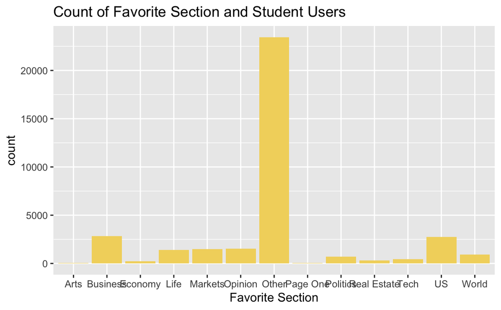

```r
ggplot(student_users, aes(student_users$favoriteSection)) + geom_bar(fill = "#f2d56b") + ggtitle("Count of Favorite Section and Student Users") + labs(x = "Favorite Section")
```

The above graph shows us that a small group of students are interested in the Politics section. We can also analyze the number of active days in the last four weeks for students. This would give a better understanding of student demographics

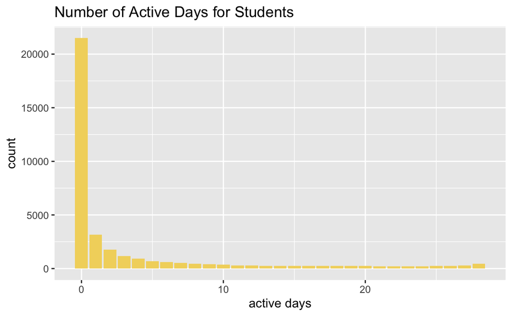

```r
ggplot(student_users, aes(student_users$activeDays)) + geom_bar(fill = "#f2d56b") + ggtitle("Number of Active Days for Students") + labs(x = "active days")
```

From the above graph we can see that students are mostly inactive and do not read as many articles. Based on this, we can say that our product target audience would not be students. If WSJ would like to have students as their target audience, it is important to find different mediums that would make it interesting for students to read/listen. For example: a podcast.

Insight #2: WSJ Mediums

```r
#aggregating data based on print media
print_data <- dataset %>% group_by(print) %>% dplyr::summarize(Total = n())
datatable(print_data)
```

|  | print | Total |
| --- | --- | --- |
| 1 | 0 | 153913 |
| 2 | 1 | 46087 |

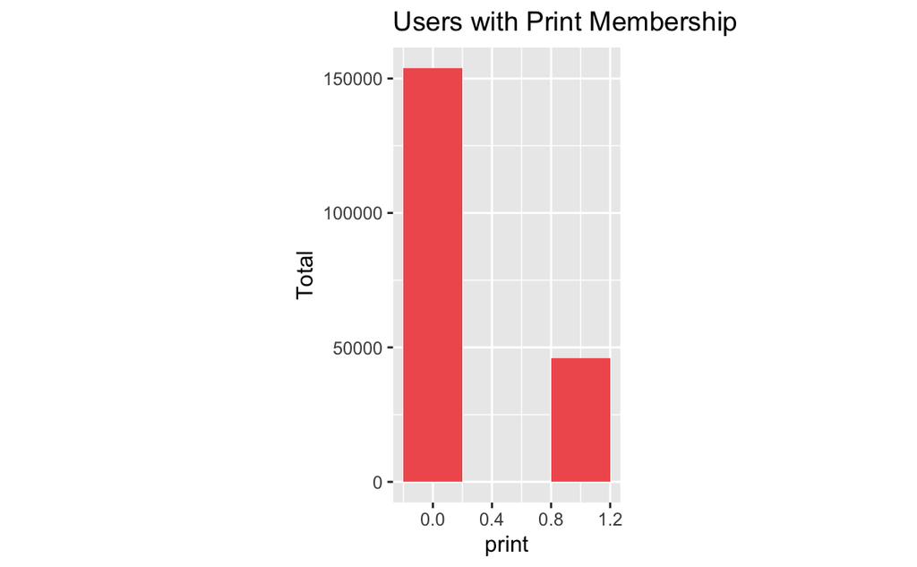

```r
#using ggplot to visualize our print data
ggplot(print_data, aes(print, Total)) + geom_bar(stat = "identity", width = 0.4, fill="#f05d5d") + ggtitle("Users with Print Membership") + theme(aspect.ratio = 2/1)
```

```r
#aggregating data based on newsletter media
newsletter_data <- dataset %>% group_by(newsletterActivated) %>% dplyr::summarize(Total = n())
datatable(newsletter_data)
```

|  | newsletterActivated | Total |
| --- | --- | --- |
| 1 | 0 | 148916 |
| 2 | 1 | 51084 |

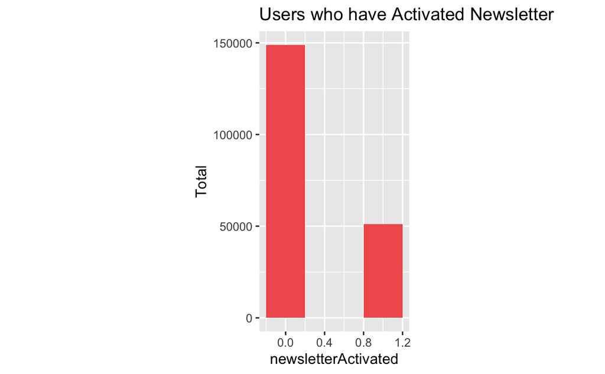

```r
#using ggplot to visualize our newsletter data
ggplot(newsletter_data, aes(newsletterActivated, Total)) + geom_bar(stat = "identity", width = 0.4, fill="#f05d5d") + ggtitle("Users who have Activated Newsletter") + theme(aspect.ratio = 2/1)
```

```r
#aggregating data based on WSJ app downloaded
app_data <- dataset %>% group_by(appActivated) %>% dplyr::summarize(Total = n())
datatable(app_data)
```

|  | appActivated | Total |
| --- | --- | --- |
| 1 | 0 | 99647 |
| 2 | 1 | 100353 |

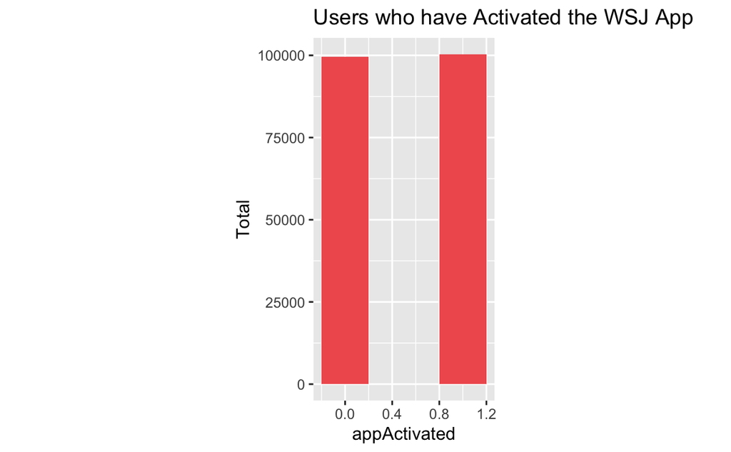

```r
#using ggplot to visualize our WSJ app activated data
ggplot(app_data, aes(appActivated, Total)) + geom_bar(stat = "identity", width = 0.4, fill="#f05d5d") + ggtitle("Users who have Activated the WSJ App") + theme(aspect.ratio = 2/1)
```

Recommendations: Based on the above data, it is recommended that the best way to deliver content for the new product would be through the WSJ app. About half of the users (~50.2%) have the app downloaded as compared the users who have subscribed to the newsletter or receive print media.

Inisght #3: Devices

```r
#aggregating data based on desktop
desktop_data <- dataset %>% group_by(desktop) %>% dplyr::summarize(Total = n())
datatable(desktop_data)
```

|  | desktop | Total |
| --- | --- | --- |
| 1 | 0 | 108738 |
| 2 | 1 | 91262 |

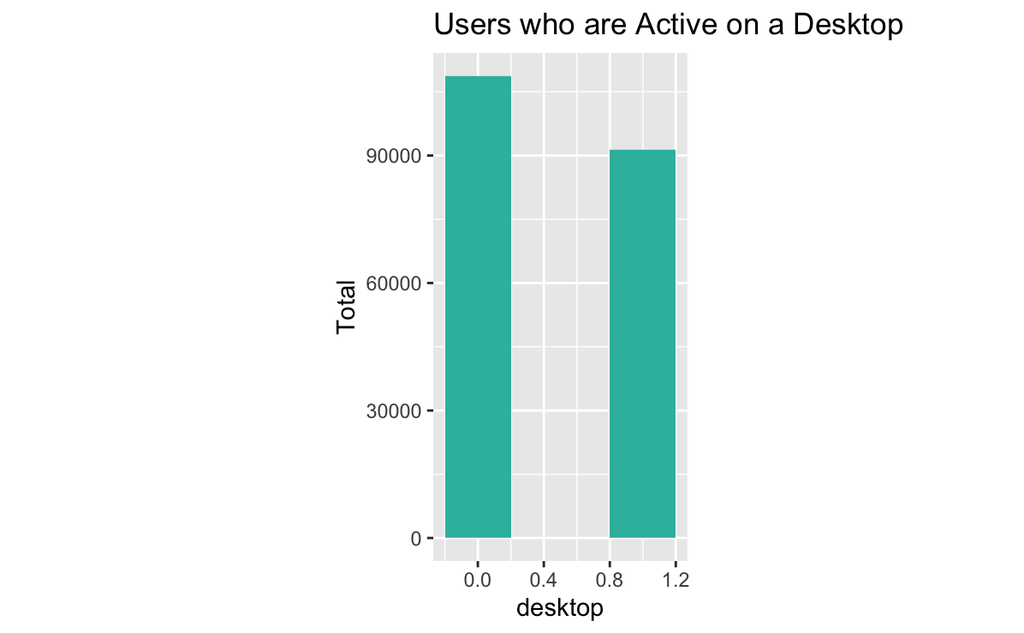

```r
#using ggplot to visualize our desktop data
ggplot(desktop_data, aes(desktop, Total)) + geom_bar(stat = "identity", width = 0.4, fill="#34baad") + ggtitle("Users who are Active on a Desktop") + theme(aspect.ratio = 2/1)
```

```r
#aggregating data based on mobile
mobile_data <- dataset %>% group_by(mobile) %>% dplyr::summarize(Total = n())
datatable(mobile_data)
```

|  | mobile | Total |
| --- | --- | --- |
| 1 | 0 | 105253 |
| 2 | 1 | 94747 |

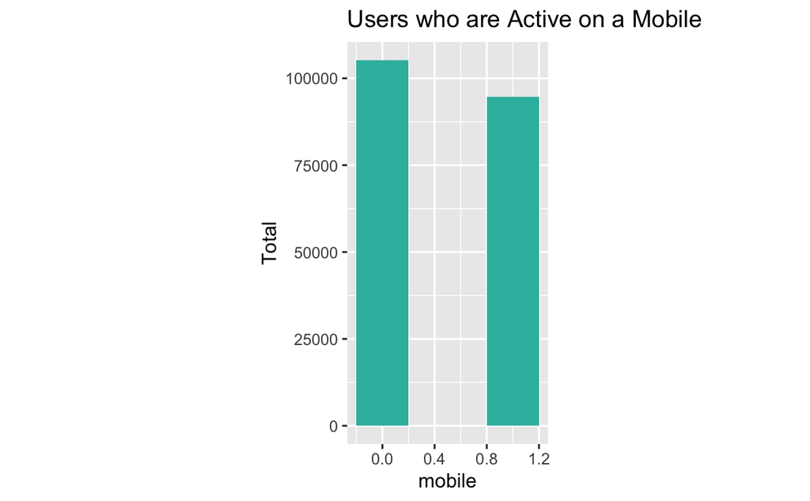

```r
#using ggplot to visualize our mobile data
ggplot(mobile_data, aes(mobile, Total)) + geom_bar(stat = "identity", width = 0.4, fill="#34baad") + ggtitle("Users who are Active on a Mobile") + theme(aspect.ratio = 2/1)
```

```r
#aggregating data based on mac
mac_data <- dataset %>% group_by(mac) %>% dplyr::summarize(Total = n())
datatable(mac_data)
```

|  | mac | Total |
| --- | --- | --- |
| 1 | 0 | 101993 |
| 2 | 1 | 98007 |

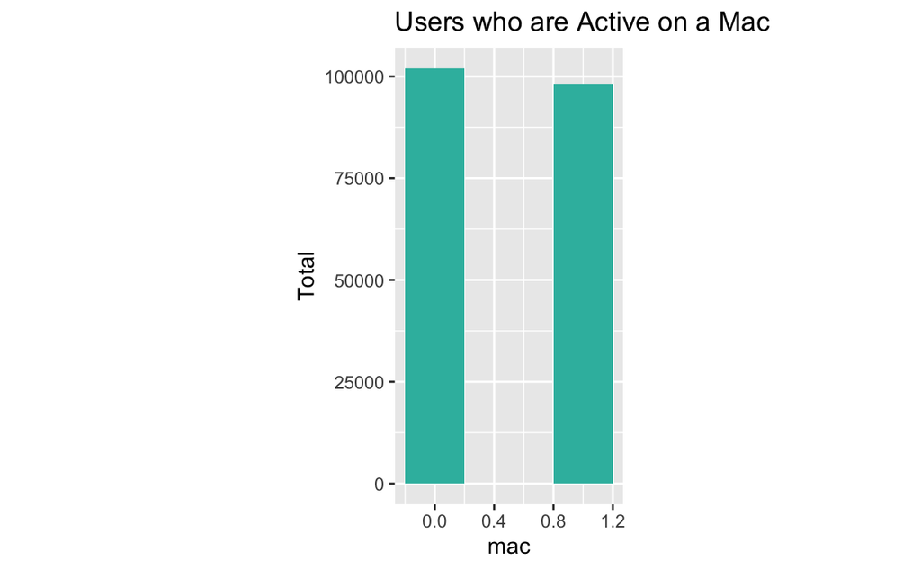

```r
#using ggplot to visualize our mac data
ggplot(mac_data, aes(mac, Total)) + geom_bar(stat = "identity", width = 0.4, fill="#34baad") + ggtitle("Users who are Active on a Mac") + theme(aspect.ratio = 2/1)
```

Insight #3: Political Affiliation

```r
#aggregating data based on affiliation and favorite section
affiliation_data <- dataset %>% group_by(`Political Affiliation`, favoriteSection) %>% dplyr::summarize(Total = n())
datatable(affiliation_data)
```

|  | Political Affiliation | favoriteSection | Total |
| --- | --- | --- | --- |
| 1 | 1 | Arts | 226 |
| 2 | 1 | Business | 7370 |
| 3 | 1 | Economy | 391 |
| 4 | 1 | Life | 4240 |
| 5 | 1 | Markets | 3694 |
| 6 | 1 | Opinion | 8847 |
| 7 | 1 | Other | 28825 |
| 8 | 1 | Page One | 128 |
| 9 | 1 | Politics | 1593 |
| 10 | 1 | Real Estate | 1469 |

[output cut: 29 more lines]

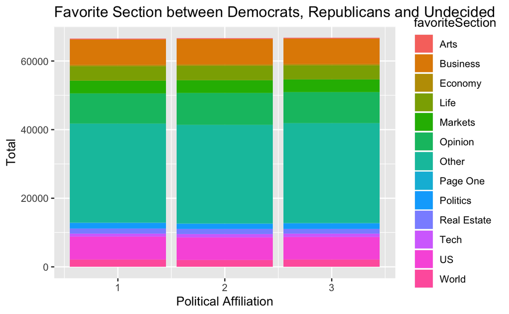

```r
ggplot(affiliation_data, aes(`Political Affiliation`, Total, fill = favoriteSection)) + geom_bar(stat = "identity") + ggtitle("Favorite Section between Democrats, Republicans and Undecided")
```

Conclusion: it seems that regardless of political party, users read the same content and have a preference for similar sections.